# Sohini’s first rmd

2022-10-17

import the data

One of the nice things about GitHub and R is that if you open up your file from the folder all the paths should be all set up. See if this code works for you. Is so then we don’t have to deal with any complicated paths to collaboratively work together

I found a couple of other Problems with the original code 1) The data file is not a .csv file. It is a text delimited file so you didn’t have the right file path. 2) I switched over to useing the read.table function which I think is easier for text files. 3) The genotype file was causing issues because someone added a website name to the bottom of the text file so it was not reading into R correctly. I went back to the original file and deleted the extra text. Now the join works.

Sohini you asked about how can we remove all the non essential backgrounds at one go? You do this by using the double equals (==) instead of the (!=) in the filtering step

```r
# Import the text file of nodule data
data_HostMutants2021_nod_counts <- read.table("../data/data_HostMutants2021_nod_counts.txt",sep = "\t",header=TRUE)

# Import the genotype information data
genotype_name <- read.table("../data/genotype_name.txt",sep = "\t",header=TRUE)

#convert the genotype_id into integer
genotype_name$genotype_id = as.integer(genotype_name$genotype_id)

#merge the two data set by 'genotype_id'
all.data<- full_join (data_HostMutants2021_nod_counts, genotype_name, by = "genotype_id")

#Select for only the A17 background
all.data.A17 <- all.data %>% filter(background=="A17")

# Remove two genotypes that did not survive/form nodules... Use the '!=' this time which says to grab all of the them BUT the named genotype ID.
all.data.A17 <- all.data.A17 %>% filter(genotype_id!="853")
all.data.A17 <- all.data.A17 %>% filter(genotype_id!="838")
```

Okay now we are ready to run a linear model with all 3 predictors!

```r
# running the linear model
model <- lm(Count ~ genotype_id + rep + type, data = all.data.A17)
summary(model)
```

```
##
## Call:
## lm(formula = Count ~ genotype_id + rep + type, data = all.data.A17)
##
## Residuals:
##     Min      1Q  Median      3Q     Max
## -462.27  -81.53   -3.60   99.02  521.04
##
## Coefficients:
##              Estimate Std. Error t value Pr(>|t|)
## (Intercept) -1436.177   3329.877  -0.431  0.66746
## genotype_id     2.446      3.954   0.619  0.53800
## repB           74.178     59.782   1.241  0.21844
## repC           49.123     59.782   0.822  0.41379
## repD            6.176     64.184   0.096  0.92359
## repE          -11.755     62.786  -0.187  0.85197
## repF          -56.129    116.834  -0.480  0.63229
## typeEarly    -580.390     65.693  -8.835  2.5e-13 ***
## typeLate     -259.978     57.813  -4.497  2.4e-05 ***
## typeWT       -333.248    119.632  -2.786  0.00672 **
## ---
## Signif. codes:  0 '***' 0.001 '**' 0.01 '*' 0.05 '.' 0.1 ' ' 1
##
## Residual standard error: 181.7 on 77 degrees of freedom
## Multiple R-squared:  0.5735, Adjusted R-squared:  0.5236
## F-statistic:  11.5 on 9 and 77 DF,  p-value: 3.203e-11
```

Right now genotype_ID only has a single co-efficient. That is because Genotype_ID is a number not a factor. We can use the column “name”” instead. We also need to make sure R understands it is a factor not a character or number!

```r
all.data.A17$name
```

```
##  [1] "dnf1"      "dnf1"      "dnf1"      "dnf1"      "dnf1"      "dnf2"
##  [7] "dnf2"      "dnf2"      "dnf2"      "dnf2"      "dnf3"      "dnf3"
## [13] "dnf3"      "dnf3"      "dnf3"      "dnf4"      "dnf4"      "dnf4"
## [19] "dnf6"      "dnf6"      "dnf6"      "dnf6"      "dnf6"      "dnf7"
## [25] "dnf7"      "dnf7"      "dnf7"      "dnf7"      "sunn1"     "sunn1"
## [31] "sunn1"     "sunn1"     "sunn1"     "sunn4"     "sunn4"     "sunn4"
## [37] "sunn4"     "sunn4"     "rdn1"      "rdn1"      "rdn1"      "latd"
## [43] "latd"      "latd"      "latd"      "latd"      "latd"      "hcl"
## [49] "hcl"       "hcl"       "hcl"       "hcl"       "nad1"      "nad1"
## [55] "nad1"      "nad1"      "ipd3"      "ipd3"      "ipd3"      "ipd3"
## [61] "dmi1-2"    "dmi1-2"    "dmi1-2"    "dmi1-2"    "dmi1-2"    "dmi2-3"
## [67] "dmi3-1"    "dmi3-1"    "dmi3-1"    "dmi3-1"    "dmi3-1"    "dmi3-1"
## [73] "dnf5/dnf2" "dnf5/dnf2" "dnf5/dnf2" "dnf5/dnf2" "dnf5/dnf2" "dnf1/dnf2"
## [79] "dnf1/dnf2" "dnf1/dnf2" "dnf1/dnf2" "dnf1/dnf2" "A17"       "A17"
## [85] "A17"       "A17"       "A17"
```

```r
#Note that this currently is a character. We need to turn it into a factor.
all.data.A17$name<-factor(all.data.A17$name)

#We need to do the same thing with type
all.data.A17$type<-factor(all.data.A17$type, levels = c("WT","Early","Late","AON"))

# Now run the model
model1 <- lm(Count ~ name + rep + type, data = all.data.A17)
summary(model)
```

```
##
## Call:
## lm(formula = Count ~ genotype_id + rep + type, data = all.data.A17)
##
## Residuals:
##     Min      1Q  Median      3Q     Max
## -462.27  -81.53   -3.60   99.02  521.04
##
## Coefficients:
##              Estimate Std. Error t value Pr(>|t|)
## (Intercept) -1436.177   3329.877  -0.431  0.66746
## genotype_id     2.446      3.954   0.619  0.53800
## repB           74.178     59.782   1.241  0.21844
## repC           49.123     59.782   0.822  0.41379
## repD            6.176     64.184   0.096  0.92359
## repE          -11.755     62.786  -0.187  0.85197
## repF          -56.129    116.834  -0.480  0.63229
## typeEarly    -580.390     65.693  -8.835  2.5e-13 ***
## typeLate     -259.978     57.813  -4.497  2.4e-05 ***
## typeWT       -333.248    119.632  -2.786  0.00672 **
## ---
## Signif. codes:  0 '***' 0.001 '**' 0.01 '*' 0.05 '.' 0.1 ' ' 1
##
## Residual standard error: 181.7 on 77 degrees of freedom
## Multiple R-squared:  0.5735, Adjusted R-squared:  0.5236
## F-statistic:  11.5 on 9 and 77 DF,  p-value: 3.203e-11
```

```r
# Run a model with name and replicate as predictors
model.name <- lm(Count ~ name + rep, data = all.data.A17)

#Examine the summary
summary(model.name)
```

```
##
## Call:
## lm(formula = Count ~ name + rep, data = all.data.A17)
##
## Residuals:
##     Min      1Q  Median      3Q     Max
## -339.43  -60.32    0.19   75.51  574.84
##
## Coefficients:
##               Estimate Std. Error t value Pr(>|t|)
## (Intercept)    335.164     76.495   4.382 4.55e-05 ***
## namedmi1-2    -360.350     99.819  -3.610 0.000607 ***
## namedmi2-3    -335.164    172.156  -1.947 0.056012 .
## namedmi3-1    -357.761     94.814  -3.773 0.000359 ***
## namednf1      -155.800     97.542  -1.597 0.115212
## namednf1/dnf2   -1.000     97.542  -0.010 0.991853
## namednf2        79.600     97.542   0.816 0.417542
## namednf3        29.600     97.542   0.303 0.762540
## namednf4       -42.368    113.575  -0.373 0.710373
## namednf5/dnf2   84.800     97.542   0.869 0.387946
## namednf6       205.800     97.542   2.110 0.038849 *
## namednf7         3.800     97.542   0.039 0.969047
## namehcl       -142.000     97.542  -1.456 0.150418
## nameipd3      -162.045    103.870  -1.560 0.123752
## namelatd      -354.595     94.814  -3.740 0.000400 ***
## namenad1         4.269    103.845   0.041 0.967337
## namerdn1       423.299    113.575   3.727 0.000417 ***
## namesunn1       57.200     97.542   0.586 0.559693
## namesunn4      440.600     97.542   4.517 2.82e-05 ***
## repB            70.833     51.409   1.378 0.173129
## repC            45.778     51.409   0.890 0.376607
## repD             9.657     55.899   0.173 0.863400
## repE           -13.087     54.654  -0.239 0.811531
## repF            22.405    103.403   0.217 0.829162
## ---
## Signif. codes:  0 '***' 0.001 '**' 0.01 '*' 0.05 '.' 0.1 ' ' 1
##
## Residual standard error: 154.2 on 63 degrees of freedom
## Multiple R-squared:  0.7485, Adjusted R-squared:  0.6567
## F-statistic: 8.153 on 23 and 63 DF,  p-value: 1.78e-11
```

```r
#Examine the Analysis of Variance table
anova(model.name)
```

```
## Analysis of Variance Table
##
## Response: Count
##           Df  Sum Sq Mean Sq F value    Pr(>F)
## name      18 4380111  243340 10.2303 1.427e-12 ***
## rep        5   80202   16040  0.6744    0.6444
## Residuals 63 1498525   23786
## ---
## Signif. codes:  0 '***' 0.001 '**' 0.01 '*' 0.05 '.' 0.1 ' ' 1
```

Sohini– type your intertation of these model results here: The genotypes influence the nodule number trait significantly( Pr(>F)=1.427e-12) while the technical replicates have no significant effect( Pr(>F)=0.6444).Among the genotypes, the dmi’s have the most pronounced effect on nodulation.None of the dmi nodulated during community inoculation indicating their absolute essentiality. latd also had a similar strong negative effect on nodulation. Among the genotypes which positively influenced nodule numbers, rdn1 and sunn4 were strong candidates with sunn4 emerging to be most influential among all the genotypes tested. Lastly, among the dnfs, only dnf6 seems to positively affect the trait while the rest had minor/non-significant effects.

```r
# Run a model with type and replicate as predictors
model.type <- lm(Count ~ type + rep, data = all.data.A17)

#Examine the summary
summary(model.type)
```

```
##
## Call:
## lm(formula = Count ~ type + rep, data = all.data.A17)
##
## Residuals:
##     Min      1Q  Median      3Q     Max
## -463.92  -82.41   -3.07   98.84  547.83
##
## Coefficients:
##             Estimate Std. Error t value Pr(>|t|)
## (Intercept)  334.506     89.337   3.744 0.000344 ***
## typeEarly   -279.342     89.059  -3.137 0.002411 **
## typeLate      26.663     85.630   0.311 0.756348
## typeAON      288.826     95.303   3.031 0.003311 **
## repB          73.898     59.543   1.241 0.218297
## repC          48.842     59.543   0.820 0.414555
## repD           6.142     63.930   0.096 0.923705
## repE         -12.411     62.528  -0.198 0.843179
## repF         -55.164    116.360  -0.474 0.636770
## ---
## Signif. codes:  0 '***' 0.001 '**' 0.01 '*' 0.05 '.' 0.1 ' ' 1
##
## Residual standard error: 181 on 78 degrees of freedom
## Multiple R-squared:  0.5714, Adjusted R-squared:  0.5274
## F-statistic:    13 on 8 and 78 DF,  p-value: 1.015e-11
```

```r
#Examine the Analysis of Variance table
p<-anova(model.type)
p
```

```
## Analysis of Variance Table
##
## Response: Count
##           Df  Sum Sq Mean Sq F value    Pr(>F)
## type       3 3297098 1099033 33.5629 4.916e-14 ***
## rep        5  107595   21519  0.6572     0.657
## Residuals 78 2554147   32745
## ---
## Signif. codes:  0 '***' 0.001 '**' 0.01 '*' 0.05 '.' 0.1 ' ' 1
```

```r
# percentage of variance explained
p<-p$"Sum Sq"
print(cbind(PctExp=p/sum(p)*100))
```

```
##         PctExp
## [1,] 55.331211
## [2,]  1.805629
## [3,] 42.863160
```

Sohini type your interpretation of the model results here: Here also the technical replicates did not affect the overall nodule numbers. The stage of nodulation strongly influenced the nodule numbers (Pr(>F) =4.916e-14),specifically the Early stage of nodulation (latd).It seems as if any mutation in the early stage of RNS negatively affects the nodule numbers. Autoregulation of nodulation pathway(AON) (rdn1,sunn4) is a significant positive influencer of nodulation.

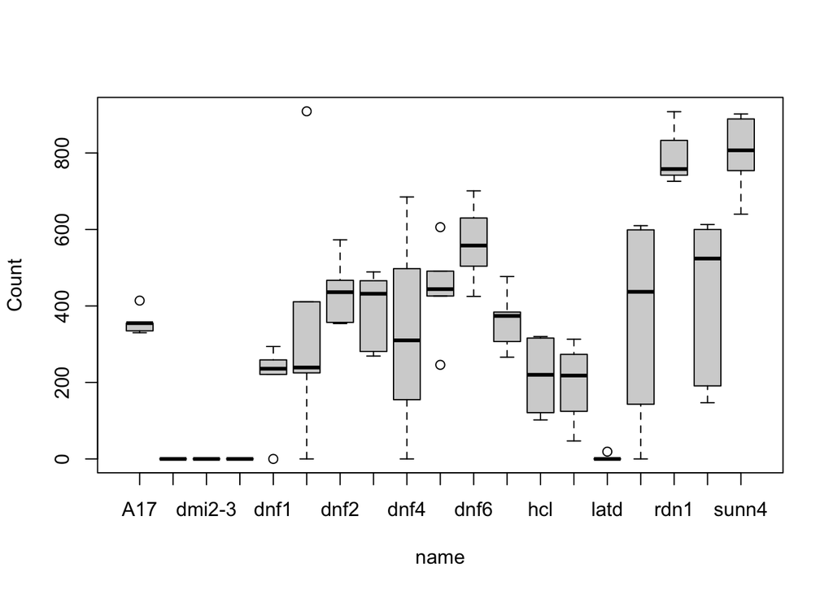

```r
#Super quick base r plot!
plot(Count~name, data=all.data.A17)
```

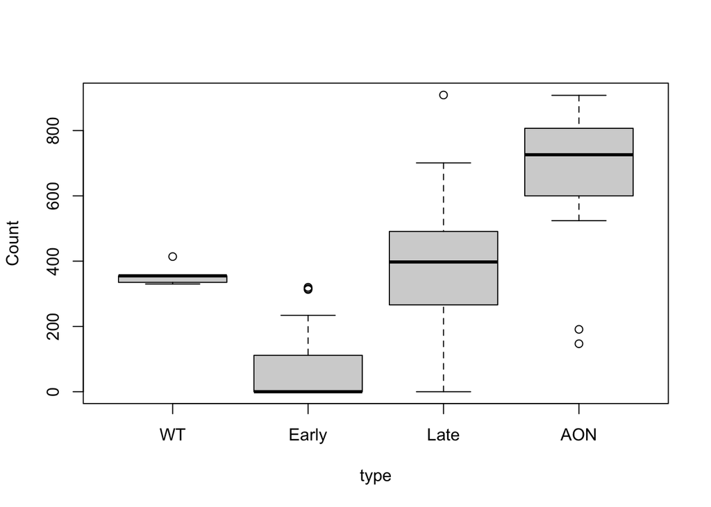

```r
#Super quick base r plot!
plot(Count~type, data=all.data.A17)
```